# 衰减方程（函数）小结 Decay Function Review

Yi DENG

December 28, 2014

# 衰减方程的应用

1. 推荐算法、排序算法。如果原始数据是一堆时间序列数据（如每天销售数据）。进行计算时，常见的想法是给近期的指标更大的权重（理由：客户近期购买的产品更能反映当前客户的偏好）。衰减方程用于生成对应时间的权值。
2. 库存管理。对易腐坏物品（库存），对其价值进行衰减。

# 几个有用的方程(函数)

| 类型 | 方程 | 当t=L | 备注 |
| --- | --- | --- | --- |
| 线性衰减 (linear) | $1 - t/L$ | 全衰 |  |
| 指数衰减（exponential） | $2^{-t/L}$ 也可写为 $e^{ -t/L * log(2)}$ | 半衰 | 2不是固定值，可调整 |
| 韦伯衰减（Weibull） | $e^{ -(t/L)^k * log(2)}$ | 半衰 | k为形状参数，实数。当k=1时，为指数衰减。 |

- 注：t为时间, L为生命衰减周期（常数）

以下是R计算代码和图形。就目前的了解，我更倾向使用韦伯分布作为估计，通过调整参数k，可以呈现不同的效果（根据需求，调整下降速度是先快后慢，还是先慢后快)

设  
$t = 1,2,…,54$ (一年54周)  
$L = 27$ （衰减周期为半年）  
$k_1 = 2$ （韦伯衰减k = 2）  
$k_2 = 0.5$ （韦伯衰减k = 0.5）

需要关注的是，  
1. 要计算的需求是全衰还是半衰  
2. 下降速率  
参考链接[1]中还提供了一种smooth-compact方程，可以用作全衰的计算。因为一时没查到相关资料，不确定该方程来源，在此暂不计算。

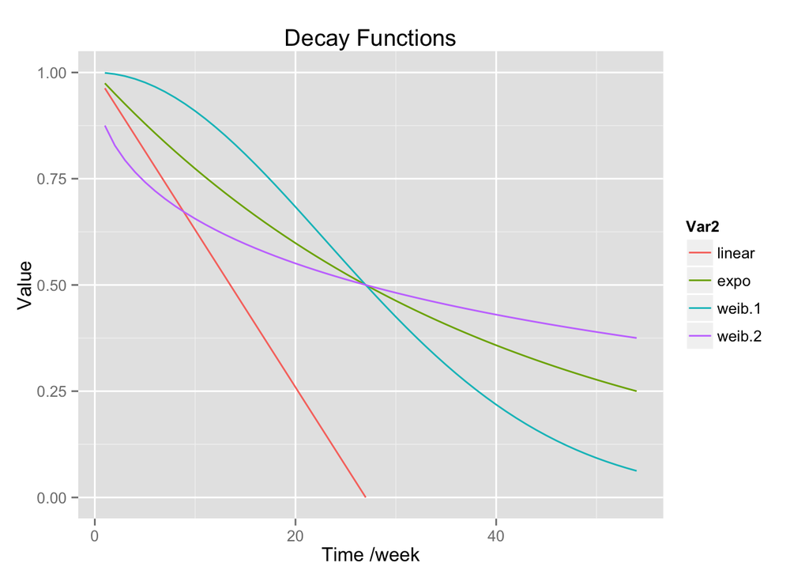

```r
# 参数设定
t <- 1:54
L <- 27
k1 <- 2
k2 <- 0.5

# 线性衰减
linear <- 1 - t/L

# 指数衰减
expo <- 2^(-t/L)

# 韦伯衰减（Weibull Decay Function）
weib.1 <- exp(-(t/L)^k1 * log(2))
weib.2 <- exp(-(t/L)^k2 * log(2))

# 画图
data <- cbind(linear, expo, weib.1, weib.2)
library(reshape2)
meltdata <- melt(data)
library(ggplot2)
ggplot(data = meltdata, ylim = 0:1,
       aes(x = Var1, y = value, color = Var2)) +
    geom_line() +
    ylim(0,1) +
    labs(title = "Decay Functions", x= "Time /week", y = "Value")
```

参考： [1]https://code.google.com/p/openmalaria/wiki/ModelDecayFunctions